# Clustering Kemiskinan

# Analasis K-Medoids

## Melakukan standarisasi data

```r
data_standarisai <- scale(index)
```

```r
library(tidyverse)  # data manipulation
library(cluster)    # clustering algorithms
library(factoextra) # clustering algorithms & visualization
```

## Penentuan jumlah cluster

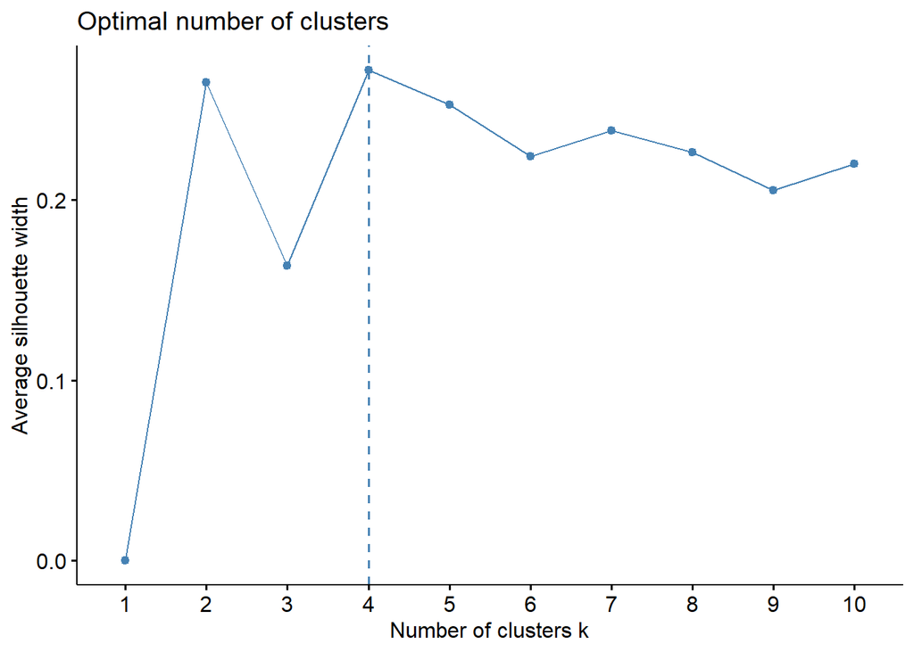

```r
# silhouette
fviz_nbclust(data_standarisai, pam, method = "silhouette")
```

```r
# pamk
library(fpc)
pamk.result <- pamk(data_standarisai)
pamk.result$nc
```

```
## [1] 4
```

### K-Medoids cluster

```r
library(cluster)
pam.result <- pam(data_standarisai,4)
print(pam.result)
```

```
## Medoids:
##             ID         X1          X2         X3         X4         X5
## Bekasi      16  0.6746563 -1.01648235  0.9924127  0.3141528 -0.3141528
## Tasikmalaya  6 -0.7086854  1.16954436 -1.1836928  0.9748709 -0.9748709
## Cirebon      9  0.4681874  0.02120285 -0.3107654 -0.1670495  0.1670495
## Kota Depok  24  0.2204247 -1.44668698  1.8575738 -1.8948898  1.8948898
##                     X6         X7         X8         X9
## Bekasi      -0.4775114  0.4087796 -1.1093444 -0.8696264
## Tasikmalaya -1.5483634 -2.3657034 -0.3961944 -1.0277402
## Cirebon      0.1662523  0.4383509  1.1681346  0.6324555
## Kota Depok   0.9828552  1.0750035 -1.9375186 -1.6601958
## Clustering vector:
##            Bogor         Sukabumi          Cianjur          Bandung
##                1                2                3                1
##            Garut      Tasikmalaya           Ciamis         Kuningan
##                2                2                3                3
##          Cirebon       Majalengka         Sumedang        Indramayu
##                3                3                3                3
##           Subang       Purwakarta         Karawang           Bekasi
##                3                3                3                1
##    Bandung Barat      Pangandaran       Kota Bogor    Kota Sukabumi
##                1                2                1                1
##     Kota Bandung     Kota Cirebon      Kota Bekasi       Kota Depok
##                1                1                4                4
##      Kota Cimahi Kota Tasikmalaya      Kota Banjar
##                4                1                2
## Objective function:
##    build     swap
## 1.956462 1.901335
##
## Available components:
##  [1] "medoids"    "id.med"     "clustering" "objective"  "isolation"
##  [6] "clusinfo"   "silinfo"    "diss"       "call"       "data"
```

### Jarak Euclidean

```r
pam.result$diss
```

```
## Dissimilarities :
##                     Bogor Sukabumi  Cianjur  Bandung    Garut Tasikmalaya
## Sukabumi         3.468442
## Cianjur          4.065629 2.703015
## Bandung          2.549139 2.933592 4.520867
## Garut            4.193667 3.134528 3.524888 4.899422
## Tasikmalaya      4.224433 2.672920 3.839909 4.283947 1.565898
## Ciamis           3.949924 2.499664 2.595402 3.089260 4.802774    4.259021
## Kuningan         4.323061 4.110796 2.220398 5.319538 4.834772    5.512686
## Cirebon          2.746140 3.119264 2.261112 3.648735 4.362910    4.698903
## Majalengka       3.999682 3.367154 1.729084 4.377135 4.180747    4.649151
## Sumedang         4.274921 3.626960 1.522140 4.604751 4.580664    4.800859
## Indramayu        4.870615 4.088309 1.823410 5.641028 4.380396    5.096165
## Subang           3.916093 4.291600 2.893169 4.786831 5.459032    5.739024
## Purwakarta       2.529072 3.247980 3.003248 2.985240 4.810298    4.973337
## Karawang         3.381329 3.408688 3.833978 3.780259 4.832303    4.854951
## Bekasi           1.922212 3.183405 4.550177 1.319120 4.971054    4.656065
## Bandung Barat    1.621961 2.316262 3.015391 2.537931 3.427956    3.347274
## Pangandaran      5.961630 5.041102 4.440864 5.961709 4.102437    3.781736
## Kota Bogor       3.171949 3.990343 4.964237 2.674314 6.025487    5.988501
## Kota Sukabumi    3.037920 2.471092 3.844496 1.991980 5.060850    4.775848
## Kota Bandung     2.193169 3.677019 4.844020 1.656880 5.587229    5.137479
## Kota Cirebon     1.990299 4.098834 4.441616 2.920603 5.700064    5.675855
## Kota Bekasi      4.350219 6.145250 6.587167 4.265713 7.791323    7.576501
## Kota Depok       4.505899 5.901866 6.882783 3.547449 7.895824    7.378989
## Kota Cimahi      3.246397 4.518852 5.102265 2.521335 6.514870    6.248990
## Kota Tasikmalaya 3.169688 3.490183 4.106222 3.610838 3.454200    3.724899
## Kota Banjar      3.560681 1.528508 2.979532 3.262200 3.065509    3.157821
##                    Ciamis Kuningan  Cirebon Majalengka Sumedang Indramayu
## Sukabumi
## Cianjur
## Bandung
## Garut
## Tasikmalaya
## Ciamis
## Kuningan         3.979508
## Cirebon          2.955495 1.827987
## Majalengka       3.073562 1.814009 1.924671
## Sumedang         2.540557 2.584933 2.512735   1.837802
## Indramayu        3.987313 1.336186 2.598158   1.521516 2.368506
```

[output cut: 84 more lines]

```
## Bekasi
## Bandung Barat
## Pangandaran
## Kota Bogor
## Kota Sukabumi
## Kota Bandung
## Kota Cirebon
## Kota Bekasi
## Kota Depok          1.787192
## Kota Cimahi         2.231367   2.116047
## Kota Tasikmalaya    6.961198   6.787780    5.187756
## Kota Banjar         6.472429   6.334160    4.711744         2.708705
##
## Metric :  euclidean
## Number of objects : 27
```

### Hasil Cluster

```r
df.cluster = data.frame(data_standarisai,pam.result$cluster)
View(df.cluster)
```

### Plot Cluster

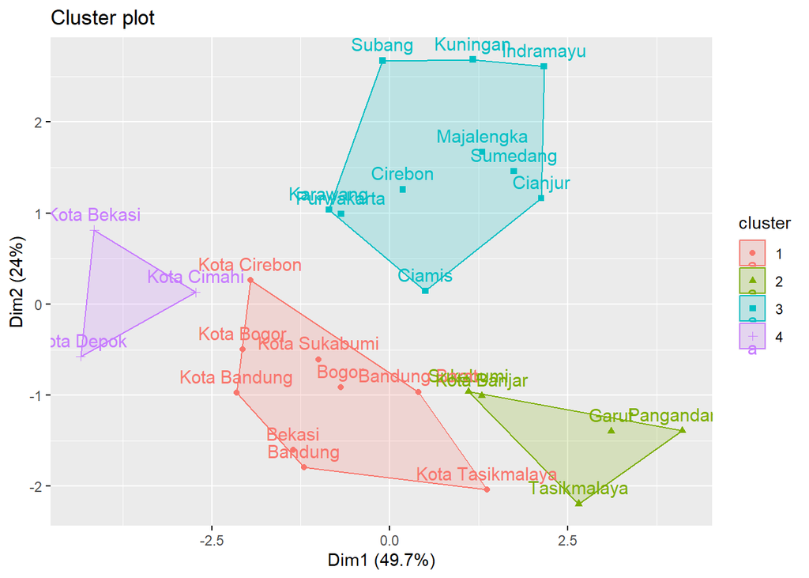

```r
fviz_cluster(pam.result, data = index)
```

```r
?fviz_cluster
```

```
## starting httpd help server ... done
```

### Silhouette Score

```r
library(cluster)
library(factoextra)

# --- 1) Hitung silhouette untuk PAM ---
sil_pam <- silhouette(pam.result$cluster, dist(data_standarisai))

# Silhouette rata-rata keseluruhan
sil_overall_pam <- mean(sil_pam[, 3])
sil_overall_pam
```

```
## [1] 0.2718594
```

```r
# --- 2) Silhouette rata-rata per klaster ---
sil_per_cluster_pam <- tapply(sil_pam[, 3], pam.result$cluster, mean)
sil_per_cluster_pam
```

```
##         1         2         3         4
## 0.2214530 0.2035214 0.2973059 0.4521533
```

```
##   cluster size ave.sil.width
## 1       1    9          0.22
## 2       2    5          0.20
## 3       3   10          0.30
## 4       4    3          0.45
```

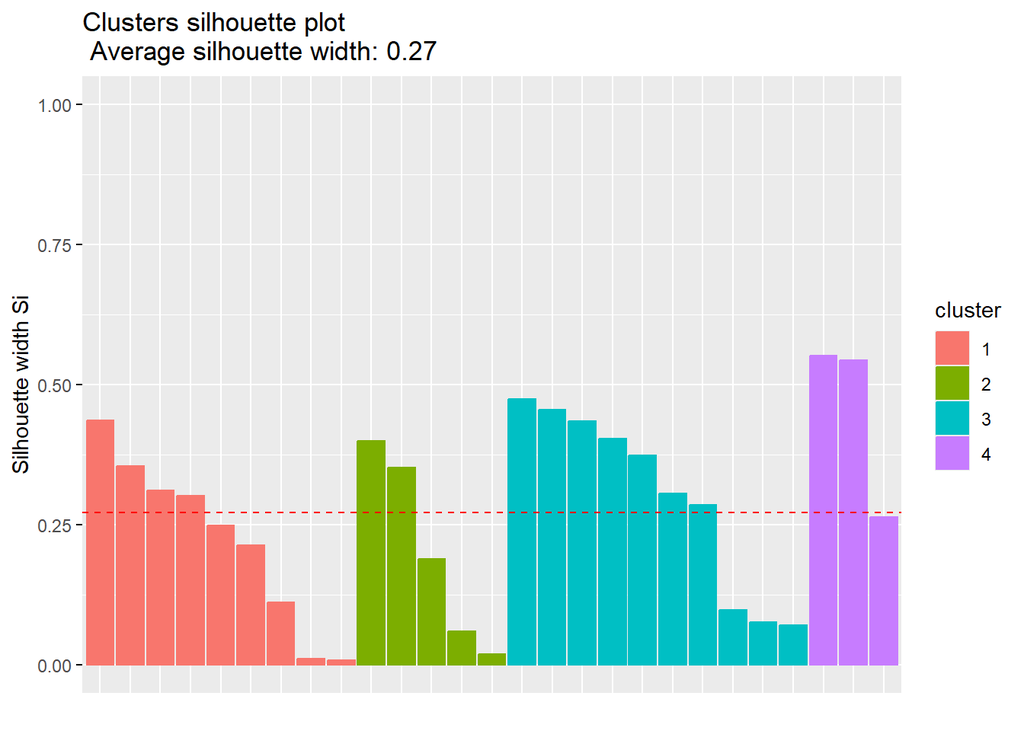

```r
# --- 3) Visualisasi silhouette ---
fviz_silhouette(sil_pam)
```

```r
# --- 4) Data frame ringkasan (mirip sil_df sebelumnya) ---
sil_df_pam <- data.frame(
  Cluster    = names(sil_per_cluster_pam),
  Silhouette = as.numeric(sil_per_cluster_pam)
)

sil_df_pam
```

```
##   Cluster Silhouette
## 1       1  0.2214530
## 2       2  0.2035214
## 3       3  0.2973059
## 4       4  0.4521533
```

Cluster 4 adalah cluster yang paling kuat, dikarenakan hampir semua objek di cluster ini memiliki nilai silhouette di atas rata-rata yaitu sebesar 0.4521533 (45.22%). Cluster 3, memiliki beberapa objek dengan nilai silhouette di atas rata-rata, tetapi terdapat objek yang berada di bawah rata-rata dengan nilai silhouette score sebesar 0.2973059 (29.73%). Cluster 2, hampir sama dengan cluster 3, tetapi memiliki objek yang berada di bawah rata-rata nilai silhouette yang lebih banyak dengan silhouette score sebesar 0.2035214 (20.35%). Cluster 1, hampir sama juga dengan cluster 2, dengan silhouette score sebesar 0.22145530 (22.16%).

Diperoleh Silhouette score dari metode k-medoids sebesar 0.2718594 atau 27.19%.

#### Karakteristik setiap cluster

1. **Cluster 1 (Merah)**

   *Cluster* ini cenderung memiliki karakteristik yang serupa dan memiliki sebaran yang cukup luas.
2. **Cluster 2 (Hijau)**

   Memiliki sebaran yang relatif padat dan terkumpul di sudut kanan bawah.
3. **Cluster 3 (Biru)**

   Memiliki sebaran yang juga luas seperti cluster 1.
4. **Cluster 4 (Ungu)**

   Memiliki sebaran yang paling kecil dengan karakteristik yang paling mirip dan paling seragam dalam kelompoknya.

### Data frame hasil pengelompokkan

```r
hasil <- data.frame(pempro, cluster = pam.result$cluster)
head(hasil)
```

```
##             Kabupaten.Kota    X1    X2    X3    X4    X5    X6    X7   X8   X9
## Bogor                Bogor 42.12 24.35 33.53 62.81 37.19 79.77 92.83 1.08 0.26
## Sukabumi          Sukabumi 40.40 37.22 22.38 67.45 32.55 94.16 89.38 0.88 0.20
## Cianjur            Cianjur 37.36 42.34 20.30 66.02 33.98 92.71 93.89 1.58 0.41
## Bandung            Bandung 38.87 26.07 35.06 64.58 35.42 91.80 94.30 0.61 0.09
## Garut                Garut 38.26 39.13 22.60 68.37 31.63 78.97 78.24 1.41 0.29
## Tasikmalaya    Tasikmalaya 36.83 41.48 21.68 67.93 32.07 79.79 80.22 1.01 0.15
##             cluster
## Bogor             1
## Sukabumi          2
## Cianjur           3
## Bandung           1
## Garut             2
## Tasikmalaya       2
```

### Save

```r
library(writexl)
#write_xlsx(mean_total,"D:\\IPB\\Pemrograman Statistka\\Rata-Rata Cluster.xlsx")
#write_xlsx(hasil,"D:\\IPB\\Pemrograman Statistka\\Clustering K-Medoid Fix.xlsx")
```

## Visualisasi

### Peta Klasterisasi

```r
library(sf)
library(dplyr)
library(ggplot2)
```

```r
#indo_kab <- st_read("D:/Pascasarjana IPB/Semester 1/Pemograman Statistika/Pempro Project/Admin2Kabupaten/idn_admbnda_adm2_bps_20200401.shp")
```

```r
# Filter Jabar + hapus waduk
#jabar_map <- indo_kab %>%
  #filter(ADM1_EN == "Jawa Barat") %>%
  #filter(!ADM2_EN %in% c("Waduk Cirata", "Cirata Reservoir", "Waduk Jatiluhur"))

# Join dengan data cluster
#jabar_cluster <- jabar_map %>%
  #left_join(hasil, by = c("ADM2_EN" = "Kabupaten_Kota"))

# Plot peta
#ggplot(jabar_cluster) +
  #geom_sf(aes(fill = factor(Cluster))) +
  #geom_sf_text(aes(label = ADM2_EN), size = 3, color = "black") +
  #scale_fill_brewer(palette = "Set2") +
  #labs(title = "Peta Cluster Kemiskinan Jawa Barat",
       #fill = "Cluster") +
  #theme_minimal()
```

### Radar Chart

```r
library(dplyr)

mean_table <- hasil %>%
  group_by(cluster) %>%
  summarise(across(starts_with("X"), mean, na.rm = TRUE))

mean_table
```

```
## # A tibble: 4 × 10
##   cluster    X1    X2    X3    X4    X5    X6    X7    X8    X9
##     <int> <dbl> <dbl> <dbl> <dbl> <dbl> <dbl> <dbl> <dbl> <dbl>
## 1       1  41.9  24.4  33.7  64.8  35.2  89.0  95.7 0.947 0.202
## 2       2  36.3  40.1  23.6  68.4  31.6  84.5  84.7 1.11  0.244
## 3       3  38.8  36.3  24.9  63.3  36.7  96.5  95.0 1.59  0.403
## 4       4  40.6  19.2  40.2  56.9  43.1 100    99.4 0.657 0.163
```

```r
# install dulu kalau belum
# install.packages("fmsb")
# install.packages("scales")

library(fmsb)
library(scales)

# Buang kolom cluster, jadikan row = cluster
radar_df <- as.data.frame(mean_table[, -1])
rownames(radar_df) <- paste0("Cluster ", mean_table$cluster)

# Baris max & min per variabel (wajib untuk fmsb)
maxs <- apply(radar_df, 2, max)
mins <- apply(radar_df, 2, min)

radar_data <- rbind(maxs, mins, radar_df)
radar_data
```

```
##                 X1       X2       X3       X4       X5        X6       X7
## 1         41.93333 40.14600 40.23333 68.39200 43.11000 100.00000 99.36333
## 2         36.27800 19.19000 23.57200 56.89000 31.60800  84.54600 84.71600
## Cluster 1 41.93333 24.35111 33.71444 64.79222 35.20778  88.97889 95.70333
## Cluster 2 36.27800 40.14600 23.57200 68.39200 31.60800  84.54600 84.71600
## Cluster 3 38.80300 36.28400 24.91300 63.27800 36.72200  96.45800 95.01400
## Cluster 4 40.57667 19.19000 40.23333 56.89000 43.11000 100.00000 99.36333
##                  X8        X9
## 1         1.5870000 0.4030000
## 2         0.6566667 0.1633333
## Cluster 1 0.9466667 0.2022222
## Cluster 2 1.1120000 0.2440000
## Cluster 3 1.5870000 0.4030000
## Cluster 4 0.6566667 0.1633333
```

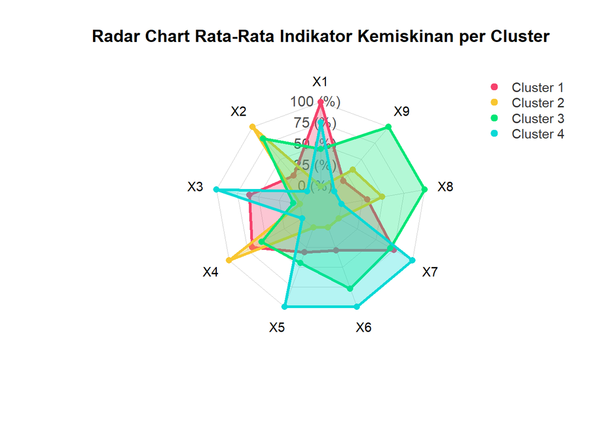

```r
# Palet warna ceria (sama vibe dengan yang barplot tadi)
colors_border <- c(
  "#F6416C",  # bubblegum pink
  "#F8C630",  # gold cerah
  "#00E676",  # turquoise cerah
  "#08D9D6"   # neon aqua
)

colors_in <- alpha(colors_border, 0.3)

radarchart(
  radar_data,
  axistype = 1,
  # garis & isi tiap cluster
  pcol = colors_border,
  pfcol = colors_in,
  plwd = 3,
  plty = 1,
  # garis grid
  cglcol = "grey80",
  cglty = 1,
  cglwd = 0.8,
  # label sumbu
  axislabcol = "grey30",
  vlcex = 0.9,
  # judul
  title = "Radar Chart Rata-Rata Indikator Kemiskinan per Cluster"
)

legend(
  "topright",
  legend = rownames(radar_data)[-c(1, 2)],  # kecuali baris max & min
  bty = "n",
  pch = 20,
  col = colors_border,
  text.col = "grey20",
  cex = 0.9,
  pt.cex = 1.6)
```

### Barplot Cluster

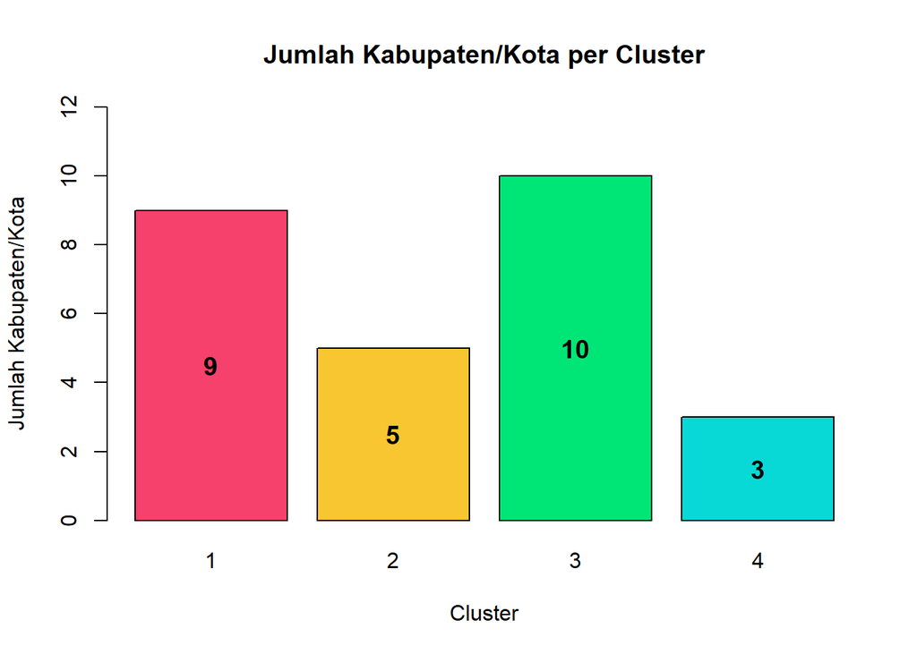

```r
# Buat tabel frekuensi
cluster_count <- table(hasil$cluster)

# Simpan posisi batang ke variabel bp
bp <- barplot(cluster_count,
              main = "Jumlah Kabupaten/Kota per Cluster",
              xlab = "Cluster",
              ylab = "Jumlah Kabupaten/Kota",
              col  = c("#F6416C", "#F8C630",
                       "#00E676","#08D9D6"),
              ylim = c(0, max(cluster_count) + 2))

# Tambahkan label di dalam batang
text(x = bp,
     y = cluster_count/2,
     labels = cluster_count,
     cex = 1.2,
     font = 2,
     col = "black")
```

### Boxplot

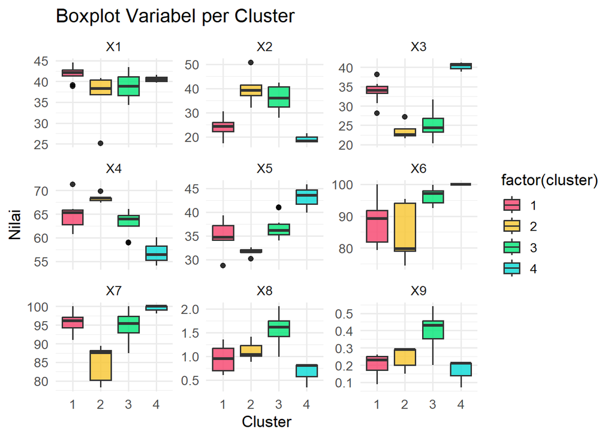

```r
library(dplyr)
library(tidyr)

data_long <- hasil %>%
  pivot_longer(
    cols = starts_with("X"),
    names_to = "variabel",
    values_to = "value"
  )
library(ggplot2)

ggplot(data_long, aes(x = factor(cluster), y = value, fill = factor(cluster))) +
  geom_boxplot(alpha = 0.8, outlier.color = "black") +
  facet_wrap(~ variabel, scales = "free_y") +
  scale_fill_manual(values = c(
    "1" = "#F6416C",  # bubblegum pink
    "2" = "#F8C630",  # gold cerah
    "3" = "#00E676",  # turquoise cerah
    "4" = "#08D9D6"   # neon aqua
  )) +
  theme_minimal(base_size = 13) +
  labs(
    title = "Boxplot Variabel per Cluster",
    x = "Cluster",
    y = "Nilai"
  )
```